# Stat 184 Final Project

Jingyu Wang

#### Load Packages

I load the packages I am going to use in this project and read in the datasets, stop words, additional stop words and the sentiments.

```r
library(rvest)
library(tidyverse)
library(genius)
library(qdap)
library(tidytext)
library(dplyr)
library(gridExtra)
data('stop_words')
data("sentiments")
additional_stop_words = read.table('AdditionalStopWords.txt')
```

## Get 1980 data from website and do the data cleaning

#### Scrape and create table of records from 1980s

Use the Xpath to get the data of records from 1980s.

```r
# read webpage for Grammy Awards
webpage <- read_html("https://en.wikipedia.org/wiki/Grammy_Award_for_Record_of_the_Year")

# copy xpath for table of 1980s
XPATH80 <- '/html/body/div[3]/div[3]/div[5]/div[1]/table[5]'

# run the following to create table of songs from 1980s
table_1980 <-
  webpage %>%
  html_nodes(xpath = XPATH80) %>%
  html_table(fill = TRUE)

d1980 <- table_1980[[1]]
```

#### Header that illustrates what how table should like like after scraping - should have 60 obs and 4 variables

In order to check the correctness of the data table.

```r
head(d1980)
```

|  | Year[I] | Record | Artist(s) | Production team |
| --- | --- | --- | --- | --- |
| 1 | 1980[44] | NA | NA | NA |
| 2 | 1980[44] | "What a Fool Believes" | The Doobie Brothers | Ted Templeman, producer |
| 3 | 1980[44] | "After the Love Has Gone" | Earth, Wind & Fire | Maurice White, producer |
| 4 | 1980[44] | "I Will Survive" | Gloria Gaynor | Freddie Perren & Dino Fekaris, producers |
| 5 | 1980[44] | "The Gambler" | Kenny Rogers | Larry Butler, producer |
| 6 | 1980[44] | "You Don't Bring Me Flowers" | Barbra Streisand & Neil Diamond | Bob Gaudio, producer |

I would like to do the data cleaning for this data, changing some column names and getting rid of the brackets.

```r
#rename the columns and get rid of the brackets in the data
ROY80s <- d1980 %>%
  na.omit() %>%
  rename(year = `Year[I]` ,track = Record, artist = `Artist(s)`) %>%
  select(year, track, artist) %>%
  mutate(year = str_replace_all(year, "\\[..\\]", ""))
```

Check whether all the things work correctly.

```r
head(ROY80s)
```

|  | year | track | artist |
| --- | --- | --- | --- |
| 1 | 1980 | "What a Fool Believes" | The Doobie Brothers |
| 2 | 1980 | "After the Love Has Gone" | Earth, Wind & Fire |
| 3 | 1980 | "I Will Survive" | Gloria Gaynor |
| 4 | 1980 | "The Gambler" | Kenny Rogers |
| 5 | 1980 | "You Don't Bring Me Flowers" | Barbra Streisand & Neil Diamond |
| 6 | 1981 | "Sailing" | Christopher Cross |

After changing everything works well, I read in the lyrics.

```r
# get lyrics for songs 1980s
lyrics80s <- ROY80s %>%
  add_genius(artist, track, type = "lyrics")
```

#### What a table for a decade (1980s) should look like - again, 2184 obs and 6 variables

```r
head(lyrics80s)
```

| year | track | artist | track_title | line | lyric |
| --- | --- | --- | --- | --- | --- |
| 1980 | "What a Fool Believes" | The Doobie Brothers | What a Fool Believes | 1 | He came from somewhere back in her long ago |
| 1980 | "What a Fool Believes" | The Doobie Brothers | What a Fool Believes | 2 | The sentimental fool don't see |
| 1980 | "What a Fool Believes" | The Doobie Brothers | What a Fool Believes | 3 | Tryin' hard to recreate |
| 1980 | "What a Fool Believes" | The Doobie Brothers | What a Fool Believes | 4 | What had yet to be created once in her life |
| 1980 | "What a Fool Believes" | The Doobie Brothers | What a Fool Believes | 5 | She musters a smile for his nostalgic tale |
| 1980 | "What a Fool Believes" | The Doobie Brothers | What a Fool Believes | 6 | Never coming near what he wanted to say |

After handling the data table for 1980s, I do the exactly the same things for the data tables from 1990s, 2000s, 2010s.

## Get 1990 data from website and do the data cleaning

```r
XPATH90 <- '//*[@id="mw-content-text"]/div[1]/table[6]'

# run the following to create table of songs from 1990s
table_1990 <-
  webpage %>%
  html_nodes(xpath = XPATH90) %>%
  html_table(fill = TRUE)

d1990 <- table_1990[[1]]
```

```r
# rename the columns and remove the brackets from the data
ROY90s <- d1990 %>%
  na.omit() %>%
  rename(year = `Year[I]` ,track = Record, artist = `Artist(s)`) %>%
  select(year, track, artist) %>%
  mutate(year = str_replace_all(year, "\\[..\\]", ""))
```

```r
#get the lyrics for 1990 nominated songs
lyrics90s <- ROY90s %>%
  add_genius(artist, track, type = "lyrics")
```

## Get 2000 data from the website and do the data cleaning

```r
# copy xpath for table of 2000s
XPATH00 <- '//*[@id="mw-content-text"]/div[1]/table[7]'

# run the following to create table of songs from 2000s
table_2000 <-
  webpage %>%
  html_nodes(xpath = XPATH00) %>%
  html_table(fill = TRUE)

d2000 <- table_2000[[1]]
```

```r
ROY00s <- d2000 %>%
  na.omit() %>%
  rename(year = `Year[I]` ,track = Record, artist = `Artist(s)`) %>%
  select(year, track, artist) %>%
  mutate(year = str_replace_all(year, "\\[..\\]", ""))
```

```r
lyrics00s <- ROY00s %>%
  add_genius(artist, track, type = "lyrics")
```

## Get 2010 data from the website and do the data cleaning

```r
# copy xpath for table of 2010s
XPATH10 <- '//*[@id="mw-content-text"]/div[1]/table[8]'

# run the following to create table of songs from 2000s
table_2010 <-
  webpage %>%
  html_nodes(xpath = XPATH10) %>%
  html_table(fill = TRUE)

d2010 <- table_2010[[1]]
```

```r
ROY10s <- d2010 %>%
  na.omit() %>%
  rename(year = `Year[I]` ,track = Record, artist = `Artist(s)`) %>%
  select(year, track, artist) %>%
  mutate(year = str_replace_all(year, "\\[..\\]", ""))
```

```r
lyrics10s <- ROY10s %>%
  add_genius(artist, track, type = "lyrics")
```

## Graph 1: Boxplots of Words per Grammy Nominated Songs by Decade

Initially, we do not need to remove the stop words. For this graph, we just visualize number of words per Grammy nominated songs by decade. I choose to use “wc” function to help me do the job and create count table for all the decades.

```r
count_80s <- lyrics80s %>%
  mutate(count = wc(lyric)) %>%
  group_by(track) %>%
  summarise(total = sum(count, na.rm = TRUE)) %>% #using na.rm = True
  mutate(year = '1980s')
```

```r
count_90s <- lyrics90s %>%
  mutate(count = wc(lyric))%>%
  group_by(track) %>%
  summarise(total = sum(count, na.rm = TRUE))%>%
  mutate(year = '1990s')
```

```r
count_00s <- lyrics00s %>%
  mutate(count = wc(lyric))%>%
  group_by(track) %>%
  summarise(total = sum(count, na.rm = TRUE))%>%
  mutate(year = '2000s')
```

```r
count_10s <- lyrics10s %>%
  mutate(count = wc(lyric))%>%
  group_by(track) %>%
  summarise(total = sum(count, na.rm = TRUE))%>%
  mutate(year = '2010s')
```

I choose to row bind the tables.

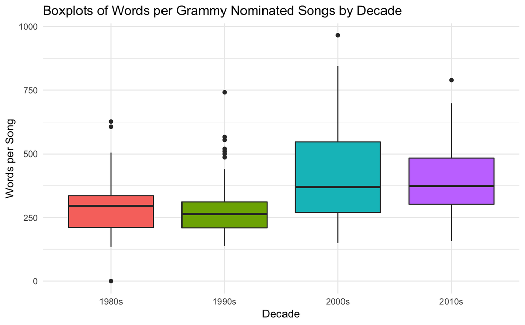

```r
count_table <- rbind(count_80s, count_90s, count_00s, count_10s)
ggplot(count_table) +
  aes(x = year, y = total, fill = year) +
  geom_boxplot() +
  scale_fill_hue() +
  labs(x = "Decade", y = "Words per Song", title = "Boxplots of Words per Grammy Nominated Songs by Decade") +
  theme_minimal() +
  theme(legend.position = "none")
```

## Graph 2: Ten Most Popular Words of Grammy Nominated Songs from 1980 - 2019

In the following parts, we need to remove the stop words from the lyrics.  
First, let’s get the stop words, putting the stop word list and the additional stop words together.  
These two datasets contain all the stop words we need to remove.

```r
additional_stop_word <- additional_stop_words %>% rename(word = V1)

##get the complete stop words list
total_stop_word <- stop_words %>%
  select(word) %>%
  rbind(additional_stop_word)
```

```r
total_lyrics <- rbind(lyrics80s, lyrics90s, lyrics00s, lyrics10s)
total_top10 <- freq_terms(total_lyrics$lyric, 10, at.least=3,stopwords=total_stop_word$word)
```

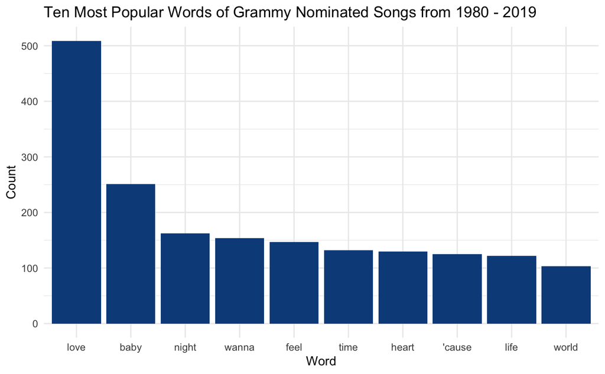

```r
total_top10%>%
  add_count(WORD, wt = FREQ) %>%
  mutate(WORD = forcats::fct_reorder(WORD, -FREQ)) %>% #in order to plot in a correct order
  ggplot() +
  aes(x = WORD, weight = FREQ) +
  geom_bar(fill = "#0c4c8a") +
  labs(x = "Word", y = "Count", title = "Ten Most Popular Words of Grammy Nominated Songs from 1980 - 2019") +
  theme_minimal()
```

## Graph 3: Top 10 by Decade

For this graph, we need to get the top 10 mostly used words in the lyrics by decade. Then, put them together. Thus, I choose to do the plot separately for each decade first.  
Top 10 for 1980s:

```r
top10_80s <- freq_terms(lyrics80s$lyric, 10, at.least=3,
                    stopwords=total_stop_word$word)
plot80 <-
  top10_80s %>%
  add_count(WORD, wt = FREQ) %>%
  mutate(WORD = forcats::fct_reorder(WORD, -FREQ)) %>%
  ggplot() +
  aes(x = WORD, weight = FREQ) +
  geom_bar(fill = "#482878") +
  labs(x = "Word", y = "Count", title = "1980s") +
  theme_minimal()
```

Top 10 for 1990s:

```r
top10_90s <- freq_terms(lyrics90s$lyric, 10, at.least=3,
                        stopwords=total_stop_word$word)
plot90 <-
  top10_90s%>%
  add_count(WORD, wt = FREQ) %>%
  mutate(WORD = forcats::fct_reorder(WORD, -FREQ)) %>%
  ggplot() +
  aes(x = WORD, weight = FREQ) +
  geom_bar(fill = "#bd3786") +
  labs(x = "Word", y = "Count", title = "1990s") +
  theme_minimal()
```

Top 10 for 2000s:

```r
top10_00s <- freq_terms(lyrics00s$lyric, 10, at.least=3,
                        stopwords=total_stop_word$word)
plot00 <-
  top10_00s%>%
  add_count(WORD, wt = FREQ) %>%
  mutate(WORD = forcats::fct_reorder(WORD, -FREQ)) %>%
  ggplot() +
  aes(x = WORD, weight = FREQ) +
  geom_bar(fill = "#26828e") +
  labs(x = "Word", y = "Count", title = "2000s") +
  theme_minimal()
```

Top 10 for 2010s:

```r
top10_10s <- freq_terms(lyrics10s$lyric, 10, at.least=3,
                        stopwords=total_stop_word$word)
plot10 <-
  top10_10s %>%
  add_count(WORD, wt = FREQ) %>%
  mutate(WORD = forcats::fct_reorder(WORD, -FREQ)) %>%
  ggplot() +
  aes(x = WORD, weight = FREQ) +
  geom_bar(fill = "#ed7953") +
  labs(x = "Word", y = "Count", title = "2010s") +
  theme_minimal()
```

Then, combine the four plots together. There are two rows and each row has two plots.

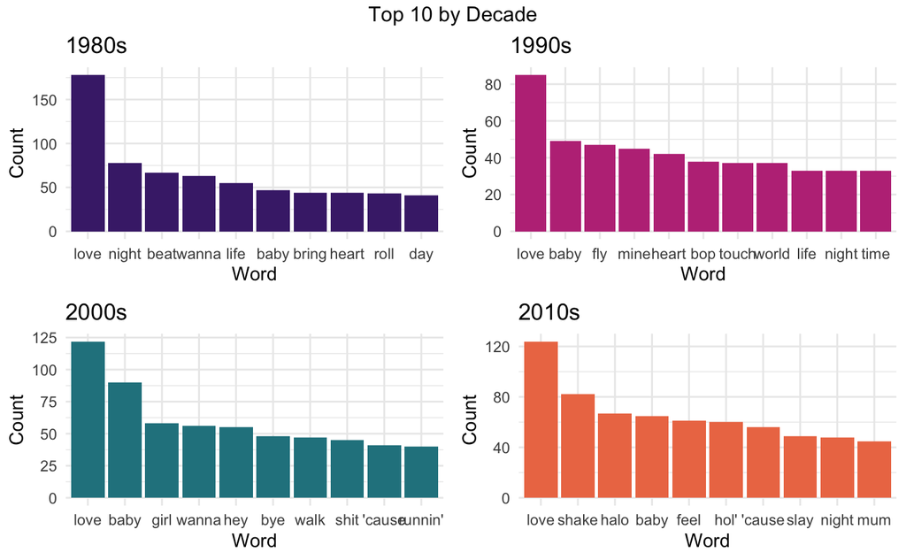

```r
grid.arrange(plot80, plot90, plot00, plot10, nrow = 2,top = "Top 10 by Decade")
```

## Graph 4: Net Sentiment Score by Year

In this graph, we are interested in the net sentiment score by year using the sentiments dataset.  
In the part of Graph 2, I have created a table called total_lyrics without filtering any stop words and the lyrics are still in a line format. I need the lyrics to be word by word in order to do the next steps.  
First, use the total_lyrics table to get rid of all the stop words.

```r
verse_words <- total_lyrics %>%
  unnest_tokens(word, lyric)

ft <- verse_words %>%
  anti_join(total_stop_word)
```

In order to get the score, I need to set the score. Based on the rubric, 1 for postive and 0 for negative.

```r
sentiment_score <- sentiments %>%
  mutate(score = ifelse(sentiment == "positive", 1, 0)) #ifelse: used to set the score for the word
```

Because I am going to sum the score, I need to get rid of any possible NA here or later. Thus, I use inner_join to find the words existing in both data tables.

```r
ft_sentiment <- ft %>%
  inner_join(sentiment_score)
```

```r
sentiment_year <- ft_sentiment %>%
  group_by(year) %>%
  summarise(sentiment_score = sum(score)) %>%
  mutate(decade = ifelse(year >= 2010, "2010s",
                         ifelse(year >= 2000, "2000s",
                                ifelse(year >= 1990, "1990s","1980s")))) %>% #The decade >>> color the plot
  mutate(year = as.numeric(year))
```

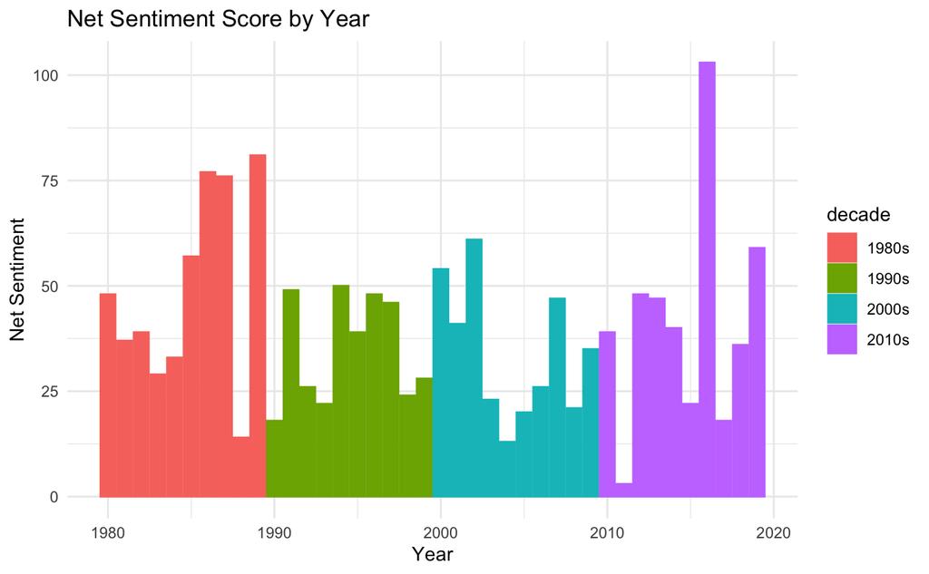

```r
ggplot(sentiment_year) +
  aes(x = year, fill = decade, colour = decade, weight = sentiment_score) +
  geom_bar() +
  scale_fill_hue() +
  scale_color_hue() +
  labs(x = "Year", y = "Net Sentiment", title = "Net Sentiment Score by Year") +
  theme_minimal()
```

## Graph 5: Mean Sentiment Score by Decade

```r
sentiment_mean <- sentiment_year %>%
  group_by(decade) %>%
  summarise(meanscore = mean(sentiment_score))
```

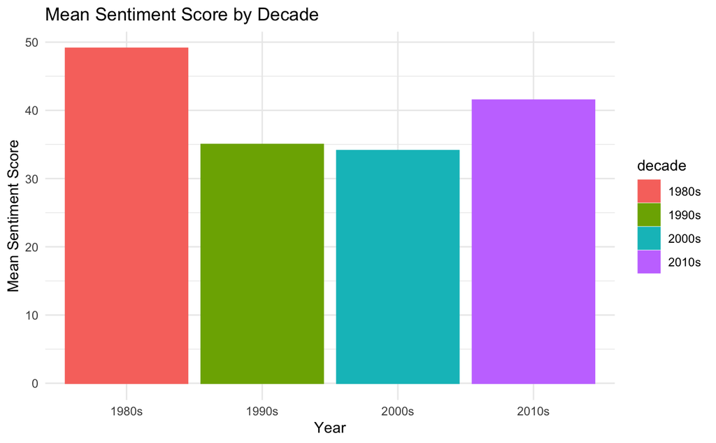

```r
ggplot(sentiment_mean) +
  aes(x = decade, fill = decade, colour = decade, weight= meanscore) +
  geom_bar() +
  labs(x = "Year", y = "Mean Sentiment Score", title = "Mean Sentiment Score by Decade") +
  theme_minimal()
```

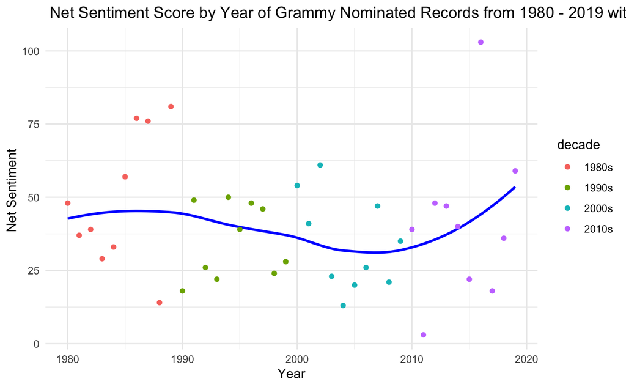

```r
ggplot(sentiment_year) +
  aes(x = year, y = sentiment_score, colour = decade) +
  geom_smooth(method = 'loess', formula = y ~ x, na.rm = TRUE, fullrange= TRUE,
              aes(group=1),colour="blue", se = FALSE) +
  geom_point() +
  scale_color_hue() +
  labs(x = "Year", y = "Net Sentiment ", title = " Net Sentiment Score by Year of Grammy Nominated Records from 1980 - 2019 with Linear Model Fit") +
  theme_minimal()
```